# Tarea 1: ENPOVE

link github: https://github.com/romloayza/econometria_tarea1

- **Alfredo Aro**
- **Romina Loayza**
- **Nicolás Gutiérrez**

### *Módulo de empleo*

```python
import pandas as pd
import os

csv_path = os.path.join("data", "ENPOVE2022_V_600 Empleo.csv")
m_empleo= pd.read_csv(csv_path,encoding = "latin-1", low_memory=False)
m_empleo.columns= m_empleo.columns.str.lower()
m_empleo
```

|  | ï»¿ccdd | departamento | ccpp | provincia | ccdi | distrito | ciudad | conglomerado | nselv | vivienda | ... | gedad1 | gedad2 | p625_d | p625_p | m622_1 | m622_2 | ingtot | ingtot_monetario | ingtot_no_monetario | factorfinal |
| --- | --- | --- | --- | --- | --- | --- | --- | --- | --- | --- | --- | --- | --- | --- | --- | --- | --- | --- | --- | --- | --- |
| 0 | 2 | ANCASH | 18 | SANTA | 1 | CHIMBOTE | Chimbote | 1206802 | 9340 | 3 | ... | 2 | 2 | 1 | 1 | 1600 | 300 | 1900 | 1600 | 300 | 13.175820 |
| 1 | 2 | ANCASH | 18 | SANTA | 1 | CHIMBOTE | Chimbote | 1206802 | 9340 | 3 | ... | 0 | 0 |  |  |  |  |  |  |  | 13.175820 |
| 2 | 2 | ANCASH | 18 | SANTA | 1 | CHIMBOTE | Chimbote | 1206802 | 9340 | 3 | ... | 3 | 3 | 1 | 1 |  |  | 1200 | 1200 | 0 | 13.175820 |
| 3 | 2 | ANCASH | 18 | SANTA | 1 | CHIMBOTE | Chimbote | 1207001 | 9345 | 6 | ... | 2 | 2 | 1 | 1 | 800 | 300 | 1100 | 800 | 300 | 26.351641 |
| 4 | 2 | ANCASH | 18 | SANTA | 1 | CHIMBOTE | Chimbote | 1207001 | 9345 | 6 | ... | 0 | 0 |  |  |  |  |  |  |  | 26.351641 |
| ... | ... | ... | ... | ... | ... | ... | ... | ... | ... | ... | ... | ... | ... | ... | ... | ... | ... | ... | ... | ... | ... |
| 11616 | 24 | TUMBES | 1 | TUMBES | 1 | TUMBES | Tumbes | 44789 | 393 | 12 | ... | 2 | 2 | 1 | 1 |  |  | 1300 | 1300 | 0 | 18.422158 |
| 11617 | 24 | TUMBES | 1 | TUMBES | 1 | TUMBES | Tumbes | 44789 | 393 | 12 | ... | 1 | 1 | 1 | 1 |  |  | 1299 | 1299 | 0 | 18.422158 |
| 11618 | 24 | TUMBES | 1 | TUMBES | 1 | TUMBES | Tumbes | 44789 | 396 | 13 | ... | 3 | 3 | 1 | 1 |  |  | 312 | 312 | 0 | 12.281439 |
| 11619 | 24 | TUMBES | 1 | TUMBES | 1 | TUMBES | Tumbes | 44789 | 396 | 13 | ... | 3 | 4 |  |  |  |  |  |  |  | 12.281439 |
| 11620 | 24 | TUMBES | 1 | TUMBES | 1 | TUMBES | Tumbes | 44789 | 397 | 14 | ... | 2 | 2 | 1 | 1 | 1500 | 300 | 1800 | 1500 | 300 | 12.281439 |

11621 rows × 156 columns

```python
import numpy as np
import seaborn as sns
import matplotlib.pyplot as plt
from scipy import stats
from tabulate import tabulate
```

### *Módulo de Características de residentes del hogar*

```python
csv_path = os.path.join("data", "ENPOVE2022_V_200_Residentes.csv")
m_residentes= pd.read_csv(csv_path,encoding = "latin-1", low_memory=False)
m_residentes.columns= m_residentes.columns.str.lower()
m_residentes
```

|  | ï»¿ccdd | departamento | ccpp | provincia | ccdi | distrito | ciudad | conglomerado | nselv | vivienda | ... | p211_n | p211_1 | p200_aportante | p211_n_parentesco | p211_n_sexo | p211_n_aãos | p211_n_meses | p211_n_ecivil | p211_n_migrante | factorfinal |
| --- | --- | --- | --- | --- | --- | --- | --- | --- | --- | --- | --- | --- | --- | --- | --- | --- | --- | --- | --- | --- | --- |
| 0 | 15 | LIMA | 1 | LIMA | 19 | LURIN | Lima | 29806 | 68378 | 12 | ... | 2 | 4.Otro |  | 2 | 2 | 29 |  | 1 | 1 | 133.030686 |
| 1 | 15 | LIMA | 1 | LIMA | 19 | LURIN | Lima | 29778 | 68073 | 9 | ... | 1 | 4.Otro |  | 1 | 2 | 35 |  | 1 | 1 | 133.030686 |
| 2 | 7 | LIMA | 1 | CALLAO | 1 | CALLAO | Lima | 1814802 | 16137 | 9 | ... | 1 | 4.Otro |  | 1 | 2 | 35 |  | 6 | 1 | 133.030686 |
| 3 | 14 | LAMBAYEQUE | 1 | CHICLAYO | 6 | LA VICTORIA | Chiclayo | 3976 | 4564 | 9 | ... | 1 | 4.Otro |  | 1 | 2 | 17 |  | 6 | 1 | 18.043333 |
| 4 | 2 | ANCASH | 18 | SANTA | 1 | CHIMBOTE | Chimbote | 12284 | 10250 | 9 | ... | 5 | 4.Otro |  | 11 | 2 | 17 |  | 1 | 1 | 26.351641 |
| ... | ... | ... | ... | ... | ... | ... | ... | ... | ... | ... | ... | ... | ... | ... | ... | ... | ... | ... | ... | ... | ... |
| 12482 | 4 | AREQUIPA | 1 | AREQUIPA | 7 | JACOBO HUNTER | Arequipa | 43374 | 14722 | 29 | ... |  |  |  |  |  |  |  |  |  | 66.313829 |
| 12483 | 4 | AREQUIPA | 1 | AREQUIPA | 7 | JACOBO HUNTER | Arequipa | 43377 | 14725 | 32 | ... |  |  |  |  |  |  |  |  |  | 132.627658 |
| 12484 | 4 | AREQUIPA | 1 | AREQUIPA | 7 | JACOBO HUNTER | Arequipa | 43377 | 14725 | 32 | ... |  |  |  |  |  |  |  |  |  | 132.627658 |
| 12485 | 4 | AREQUIPA | 1 | AREQUIPA | 7 | JACOBO HUNTER | Arequipa | 43410 | 14694 | 7 | ... |  |  |  |  |  |  |  |  |  | 132.627658 |
| 12486 | 4 | AREQUIPA | 1 | AREQUIPA | 7 | JACOBO HUNTER | Arequipa | 43410 | 14694 | 7 | ... |  |  |  |  |  |  |  |  |  | 132.627658 |

12487 rows × 42 columns

### Debemos hacer un merge

Esto para poder obtener el dato de jefe del hogar y poder compararlos con sus respuestas en el módulo de empleo...

```python
columnas_comunes = ['ï»¿ccdd', 'ccpp', 'ccdi', 'conglomerado', 'nselv', 'vivienda', 'thogar', 'nhogar', 'p200_n']
```

```python
print("Contenido de las columnas comunes en m_residentes:")
print(m_residentes[columnas_comunes].head())

print("\nContenido de las columnas comunes en m_empleo:")
print(m_empleo[columnas_comunes].head())
```

```
Contenido de las columnas comunes en m_residentes:
   ï»¿ccdd  ccpp  ccdi  conglomerado  nselv  vivienda  thogar  nhogar  p200_n
0       15     1    19         29806  68378        12       1       1       5
1       15     1    19         29778  68073         9       1       1       6
2        7     1     1       1814802  16137         9       1       1       5
3       14     1     6          3976   4564         9       1       1       1
4        2    18     1         12284  10250         9       1       1       5

Contenido de las columnas comunes en m_empleo:
   ï»¿ccdd  ccpp  ccdi  conglomerado  nselv  vivienda  thogar  nhogar  p200_n
0        2    18     1       1206802   9340         3       1       1       1
1        2    18     1       1206802   9340         3       1       1       4
2        2    18     1       1206802   9340         3       1       1       5
3        2    18     1       1207001   9345         6       1       1       1
4        2    18     1       1207001   9345         6       1       1       2
```

#### **Creamos un código único**

Esto para poder identificar a cada persona encuestada en ambas bases de datos y poder hacer un merge en base a ese valor

```python
m_residentes['codigo_unico'] = m_residentes[columnas_comunes].astype(str).agg('-'.join, axis=1)
m_empleo['codigo_unico'] = m_empleo[columnas_comunes].astype(str).agg('-'.join, axis=1)
```

```python
for columna in columnas_comunes:
    m_residentes[columna] = m_residentes[columna].astype(str).str.strip()
    m_empleo[columna] = m_empleo[columna].astype(str).str.strip()
```

```python
coincidencias = m_residentes['codigo_unico'].isin(m_empleo['codigo_unico'])
coincidencias
```

```
0        True
1        True
2        True
3        True
4        True
         ...
12482    True
12483    True
12484    True
12485    True
12486    True
Name: codigo_unico, Length: 12487, dtype: bool
```

```python
venezolanos = pd.merge(m_residentes, m_empleo, on='codigo_unico', how='inner', suffixes=('_residente', '_empleo'))
```

Verificamos las columnas que se duplican y nos quedamos con las que aparecen en 'm_empleo'...

```python
columnas_residente = set(venezolanos.filter(regex='_residente').columns)
columnas_empleo = set(venezolanos.filter(regex='_empleo').columns)
```

```python
for col_residente in columnas_residente:
    # Identificar el nombre base de la columna
    col_base = col_residente.replace('_residente', '')
    col_empleo = col_base + '_empleo'

    if col_empleo in columnas_empleo:
        # Priorizar la columna de m_empleo
        venezolanos[col_base] = venezolanos[col_empleo]
        # Eliminar las columnas duplicadas
        venezolanos.drop([col_residente, col_empleo], axis=1, inplace=True)
```

### **Selección de variables**

- p203: ¿Cuál es la relación de parentesco con el/la jefa del hogar? **[Categórica]**
- p204: Sexo **[Categórica]**
- p205_a: Edad en años **[Numérica]**
- p208: ¿Migró de Venezuela? **[Categórica]** - esta variable es más que todo para asegurar que todos hayan dicho que 'sí'
- p613: Usted, ¿ha firmado algún contrato laboral o brindó algún comprobante de pago por sus servicios? **[Categórica]**
- p616a: Normalmente, ¿Cuántas horas trabaja a la semana en todas sus ocupaciones? **[Numérica]**
- p622_1: ¿Cuánto fue su ingreso total sin descuento en el mes anterior? **[Numérica]**
- p636: En Venezuela, ¿tenía usted trabajo antes de iniciar su viaje? **[Categórica]**

```python
variables =['p203','p204', 'p205_a', 'p208', 'p613', 'p622_1', 'p636', 'estrato', 'p616a']
filtraditos = venezolanos[variables].copy()
filtraditos
```

|  | p203 | p204 | p205_a | p208 | p613 | p622_1 | p636 | estrato | p616a |
| --- | --- | --- | --- | --- | --- | --- | --- | --- | --- |
| 0 | 8.Otro pariente | 2.Mujer | 16 | 1.Sí |  |  | 2 | 4 |  |
| 1 | 4.Yerno/nuera | 2.Mujer | 17 | 1.Sí |  |  | 2 | 4 |  |
| 2 | 4.Yerno/nuera | 2.Mujer | 17 | 1.Sí |  |  | 2 | 3 |  |
| 3 | 1.Jefe/a del hogar | 2.Mujer | 17 | 1.Sí | 2 | 30 | 2 | 4 |  |
| 4 | 11.Otro no pariente | 2.Mujer | 17 | 1.Sí |  |  | 2 | 4 |  |
| ... | ... | ... | ... | ... | ... | ... | ... | ... | ... |
| 11616 | 2.Esposo/a o compañero/a | 2.Mujer | 31 | 1.Sí | 2 | 830 | 2 | 3 |  |
| 11617 | 1.Jefe/a del hogar | 1.Hombre | 30 | 1.Sí | 1 | 800 | 1 | 4 |  |
| 11618 | 2.Esposo/a o compañero/a | 2.Mujer | 25 | 1.Sí | 1 | 300 | 2 | 4 |  |
| 11619 | 1.Jefe/a del hogar | 1.Hombre | 48 | 1.Sí | 2 | 270 | 1 | 2 |  |
| 11620 | 3.Hijo/a o hijastro/a | 1.Hombre | 17 | 1.Sí |  |  | 2 | 2 |  |

11621 rows × 9 columns

```python
import warnings
warnings.filterwarnings('ignore')
filtraditos = filtraditos.applymap(lambda x: ''.join(filter(str.isdigit, str(x))))
filtraditos
```

|  | p203 | p204 | p205_a | p208 | p613 | p622_1 | p636 | estrato | p616a |
| --- | --- | --- | --- | --- | --- | --- | --- | --- | --- |
| 0 | 8 | 2 | 16 | 1 |  |  | 2 | 4 |  |
| 1 | 4 | 2 | 17 | 1 |  |  | 2 | 4 |  |
| 2 | 4 | 2 | 17 | 1 |  |  | 2 | 3 |  |
| 3 | 1 | 2 | 17 | 1 | 2 | 30 | 2 | 4 |  |
| 4 | 11 | 2 | 17 | 1 |  |  | 2 | 4 |  |
| ... | ... | ... | ... | ... | ... | ... | ... | ... | ... |
| 11616 | 2 | 2 | 31 | 1 | 2 | 830 | 2 | 3 |  |
| 11617 | 1 | 1 | 30 | 1 | 1 | 800 | 1 | 4 |  |
| 11618 | 2 | 2 | 25 | 1 | 1 | 300 | 2 | 4 |  |
| 11619 | 1 | 1 | 48 | 1 | 2 | 270 | 1 | 2 |  |
| 11620 | 3 | 1 | 17 | 1 |  |  | 2 | 2 |  |

11621 rows × 9 columns

```python
filtraditos['p203'] = pd.to_numeric(filtraditos['p203'], errors='coerce')
filtraditos['p204'] = pd.to_numeric(filtraditos['p204'], errors='coerce')
filtraditos['p205_a'] = pd.to_numeric(filtraditos['p205_a'], errors='coerce')
filtraditos['p208'] = pd.to_numeric(filtraditos['p208'], errors='coerce')
filtraditos['p613'] = pd.to_numeric(filtraditos['p613'], errors='coerce')
filtraditos['p636'] = pd.to_numeric(filtraditos['p636'], errors='coerce')
filtraditos['estrato'] = pd.to_numeric(filtraditos['estrato'], errors='coerce')
```

**Damos las etiquetas a las variables...**

```python
filtraditos['p203'] = filtraditos['p203'].apply(lambda x: 'jefe' if x == 1 else 'no_jefe')

filtraditos['p204'] = filtraditos['p204'].apply(lambda x: 'hombre' if x == 1 else 'mujer')

filtraditos['grupo_etario'] = pd.cut(filtraditos['p205_a'],
                                     bins=[0, 17, 34, 64, float('inf')],
                                     labels=['menor', 'joven', 'adulto', 'adulto mayor'])

filtraditos['p208'] = filtraditos['p208'].apply(lambda x: 'si' if x == 1 else 'no')

filtraditos['p613'] = filtraditos['p613'].apply(lambda x: 'si' if x == 1 else 'no')

filtraditos['p636'] = filtraditos['p636'].apply(lambda x: 'si' if x == 1 else 'no')

filtraditos['estrato'] = filtraditos['estrato'].apply(lambda x: 'bajo' if x == 1
                                                     else 'medio_bajo' if x == 2
                                                     else 'medio' if x == 3
                                                     else 'medio_alto' if x == 4
                                                     else 'alto' if x == 5
                                                     else 'no_especifica')

filtraditos
```

|  | p203 | p204 | p205_a | p208 | p613 | p622_1 | p636 | estrato | p616a | grupo_etario |
| --- | --- | --- | --- | --- | --- | --- | --- | --- | --- | --- |
| 0 | no_jefe | mujer | 16.0 | si | no |  | no | medio_alto |  | menor |
| 1 | no_jefe | mujer | 17.0 | si | no |  | no | medio_alto |  | menor |
| 2 | no_jefe | mujer | 17.0 | si | no |  | no | medio |  | menor |
| 3 | jefe | mujer | 17.0 | si | no | 30 | no | medio_alto |  | menor |
| 4 | no_jefe | mujer | 17.0 | si | no |  | no | medio_alto |  | menor |
| ... | ... | ... | ... | ... | ... | ... | ... | ... | ... | ... |
| 11616 | no_jefe | mujer | 31.0 | si | no | 830 | no | medio |  | joven |
| 11617 | jefe | hombre | 30.0 | si | si | 800 | si | medio_alto |  | joven |
| 11618 | no_jefe | mujer | 25.0 | si | si | 300 | no | medio_alto |  | joven |
| 11619 | jefe | hombre | 48.0 | si | no | 270 | si | medio_bajo |  | adulto |
| 11620 | no_jefe | hombre | 17.0 | si | no |  | no | medio_bajo |  | menor |

11621 rows × 10 columns

```python
filtraditos.rename(columns={
    'p203': 'jefe_hogar',
    'p204': 'sexo',
    'p205_a': 'edad',
    'p208': 'migracion_venezuela',
    'p613': 'firma_contrato',
    'p636': 'trabajo_venezuela',
    'p622_1': 'ingreso_mensual',
    'p616a' : 'horas_trabaja_sem'
}, inplace=True)
filtraditos
```

|  | jefe_hogar | sexo | edad | migracion_venezuela | firma_contrato | ingreso_mensual | trabajo_venezuela | estrato | horas_trabaja_sem | grupo_etario |
| --- | --- | --- | --- | --- | --- | --- | --- | --- | --- | --- |
| 0 | no_jefe | mujer | 16.0 | si | no |  | no | medio_alto |  | menor |
| 1 | no_jefe | mujer | 17.0 | si | no |  | no | medio_alto |  | menor |
| 2 | no_jefe | mujer | 17.0 | si | no |  | no | medio |  | menor |
| 3 | jefe | mujer | 17.0 | si | no | 30 | no | medio_alto |  | menor |
| 4 | no_jefe | mujer | 17.0 | si | no |  | no | medio_alto |  | menor |
| ... | ... | ... | ... | ... | ... | ... | ... | ... | ... | ... |
| 11616 | no_jefe | mujer | 31.0 | si | no | 830 | no | medio |  | joven |
| 11617 | jefe | hombre | 30.0 | si | si | 800 | si | medio_alto |  | joven |
| 11618 | no_jefe | mujer | 25.0 | si | si | 300 | no | medio_alto |  | joven |
| 11619 | jefe | hombre | 48.0 | si | no | 270 | si | medio_bajo |  | adulto |
| 11620 | no_jefe | hombre | 17.0 | si | no |  | no | medio_bajo |  | menor |

11621 rows × 10 columns

```python
filtraditos.info()
```

```
<class 'pandas.core.frame.DataFrame'>
RangeIndex: 11621 entries, 0 to 11620
Data columns (total 10 columns):
 #   Column               Non-Null Count  Dtype
---  ------               --------------  -----
 0   jefe_hogar           11621 non-null  object
 1   sexo                 11621 non-null  object
 2   edad                 11395 non-null  float64
 3   migracion_venezuela  11621 non-null  object
 4   firma_contrato       11621 non-null  object
 5   ingreso_mensual      11621 non-null  object
 6   trabajo_venezuela    11621 non-null  object
 7   estrato              11621 non-null  object
 8   horas_trabaja_sem    11621 non-null  object
 9   grupo_etario         11395 non-null  category
dtypes: category(1), float64(1), object(8)
memory usage: 828.8+ KB
```

## 1. Ingreso Mensual

```python
filtraditos['ingreso_mensual'] = pd.to_numeric(filtraditos['ingreso_mensual'], errors='coerce')
```

```python
print("Media:", round(filtraditos['ingreso_mensual'].mean(),2))
print("Mediana:", round(filtraditos['ingreso_mensual'].median(),2))
print("Desviación estándar:", round(filtraditos['ingreso_mensual'].std(),2))
print("Varianza:", round(filtraditos['ingreso_mensual'].var(),2))
print("Moda:", filtraditos['ingreso_mensual'].mode()[0])
print("Valor mínimo:", filtraditos['ingreso_mensual'].min())
print("Valor máximo:", filtraditos['ingreso_mensual'].max())
```

```
Media: 511.03
Mediana: 330.0
Desviación estándar: 620.28
Varianza: 384749.81
Moda: 300.0
Valor mínimo: 0.0
Valor máximo: 9500.0
```

[figure not shown]

```python
sns.histplot(filtraditos['ingreso_mensual'], kde=True, color="green", bins=10)

plt.title("Distribución incondicional del ingreso")
plt.xlabel("Ingreso mensual, en decenas de millones (S/)")
plt.ylabel("Frecuencia")
plt.show()
```

```python
filtraditos['log_ingreso_mensual'] = filtraditos['ingreso_mensual'].apply(lambda x: np.log(x) if x > 0 else np.nan)
filtraditos
```

|  | jefe_hogar | sexo | edad | migracion_venezuela | firma_contrato | ingreso_mensual | trabajo_venezuela | estrato | horas_trabaja_sem | grupo_etario | log_ingreso_mensual |
| --- | --- | --- | --- | --- | --- | --- | --- | --- | --- | --- | --- |
| 0 | no_jefe | mujer | 16.0 | si | no | NaN | no | medio_alto |  | menor | NaN |
| 1 | no_jefe | mujer | 17.0 | si | no | NaN | no | medio_alto |  | menor | NaN |
| 2 | no_jefe | mujer | 17.0 | si | no | NaN | no | medio |  | menor | NaN |
| 3 | jefe | mujer | 17.0 | si | no | 30.0 | no | medio_alto |  | menor | 3.401197 |
| 4 | no_jefe | mujer | 17.0 | si | no | NaN | no | medio_alto |  | menor | NaN |
| ... | ... | ... | ... | ... | ... | ... | ... | ... | ... | ... | ... |
| 11616 | no_jefe | mujer | 31.0 | si | no | 830.0 | no | medio |  | joven | 6.721426 |
| 11617 | jefe | hombre | 30.0 | si | si | 800.0 | si | medio_alto |  | joven | 6.684612 |
| 11618 | no_jefe | mujer | 25.0 | si | si | 300.0 | no | medio_alto |  | joven | 5.703782 |
| 11619 | jefe | hombre | 48.0 | si | no | 270.0 | si | medio_bajo |  | adulto | 5.598422 |
| 11620 | no_jefe | hombre | 17.0 | si | no | NaN | no | medio_bajo |  | menor | NaN |

11621 rows × 11 columns

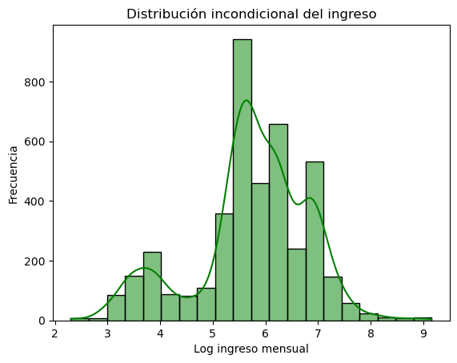

```python
sns.histplot(filtraditos['log_ingreso_mensual'], kde=True, color="green", bins=20)
plt.title("Distribución incondicional del ingreso")
plt.xlabel("Log ingreso mensual")
plt.ylabel("Frecuencia")
plt.show()
```

## 2. Cantidad de horas trabajadas a la semana

```python
filtraditos['horas_trabaja_sem'] = pd.to_numeric(filtraditos['horas_trabaja_sem'], errors='coerce')
```

```python
print("Media:", round(filtraditos['horas_trabaja_sem'].mean(),2))
print("Mediana:", round(filtraditos['horas_trabaja_sem'].median(),2))
print("Desviación estándar:", round(filtraditos['horas_trabaja_sem'].std(),2))
print("Varianza:", round(filtraditos['horas_trabaja_sem'].var(),2))
print("Moda:", filtraditos['horas_trabaja_sem'].mode()[0])
print("Valor mínimo:", filtraditos['horas_trabaja_sem'].min())
print("Valor máximo:", filtraditos['horas_trabaja_sem'].max())
```

```
Media: 50.79
Mediana: 50.0
Desviación estándar: 20.56
Varianza: 422.9
Moda: 60.0
Valor mínimo: 2.0
Valor máximo: 110.0
```

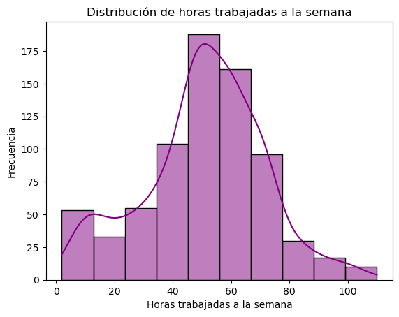

```python
sns.histplot(filtraditos['horas_trabaja_sem'], kde=True, color="purple", bins=10)

plt.title("Distribución de horas trabajadas a la semana")
plt.xlabel("Horas trabajadas a la semana")
plt.ylabel("Frecuencia")
plt.show()
```

### 2.1. *Distribución en base al sexo*

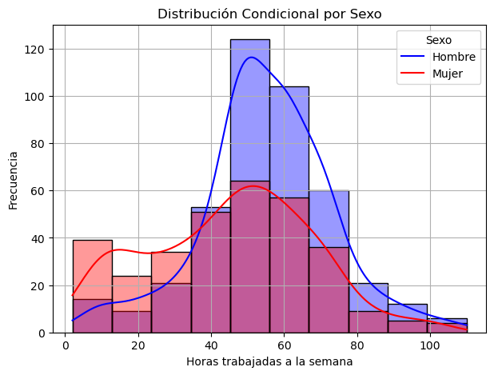

```python
plt.figure(figsize=(7, 5))
sns.histplot(filtraditos, x='horas_trabaja_sem', hue='sexo', kde=True, bins=10,
             palette={'hombre': "blue", 'mujer': "red"}, alpha=0.4)

# Ajustes del gráfico
plt.title("Distribución Condicional por Sexo")
plt.xlabel("Horas trabajadas a la semana")
plt.ylabel("Frecuencia")
plt.legend(labels=["Hombre", "Mujer"], title="Sexo")
plt.grid(True)
plt.show()
```

```python
est_hora_sexo = filtraditos.groupby('sexo')['horas_trabaja_sem'].agg(
    Media='mean',
    Mediana='median',
    Desv_Est='std',
    Varianza='var',
    Mínimo='min',
    Máximo='max',
    Moda=lambda x: x.mode()[0] if not x.mode().empty else None
).reset_index()

est_hora_sexo = est_hora_sexo.round(2)
print(tabulate(est_hora_sexo, headers='keys', tablefmt='grid'))
```

```
+----+--------+---------+-----------+------------+------------+----------+----------+--------+
|    | sexo   |   Media |   Mediana |   Desv_Est |   Varianza |   Mínimo |   Máximo |   Moda |
+====+========+=========+===========+============+============+==========+==========+========+
|  0 | hombre |   55.09 |        54 |      18.05 |     325.93 |        4 |      110 |     60 |
+----+--------+---------+-----------+------------+------------+----------+----------+--------+
|  1 | mujer  |   45.15 |        48 |      22.26 |     495.3  |        2 |      100 |     48 |
+----+--------+---------+-----------+------------+------------+----------+----------+--------+
```

### 2.2. Distribución en base al grupo etario

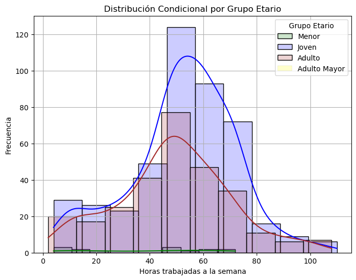

```python
plt.figure(figsize=(8, 6))

# Gráfico para Menor
sns.histplot(data=filtraditos[filtraditos['grupo_etario'] == 'menor'], x='horas_trabaja_sem', kde=True, bins=10,
             color="green", alpha=0.2, label="Menor")

# Gráfico para Joven
sns.histplot(data=filtraditos[filtraditos['grupo_etario'] == 'joven'], x='horas_trabaja_sem', kde=True, bins=10,
             color="blue", alpha=0.2, label="Joven")

# Gráfico para Adulto
sns.histplot(data=filtraditos[filtraditos['grupo_etario'] == 'adulto'], x='horas_trabaja_sem', kde=True, bins=10,
             color="brown", alpha=0.2, label="Adulto")

# Gráfico para Adulto Mayor
sns.histplot(data=filtraditos[filtraditos['grupo_etario'] == 'adulto mayor'], x='horas_trabaja_sem', kde=True, bins=10,
             color="yellow", alpha=0.2, label="Adulto Mayor")

# Ajustes del gráfico
plt.title("Distribución Condicional por Grupo Etario")
plt.xlabel("Horas trabajadas a la semana")
plt.ylabel("Frecuencia")
plt.legend(title="Grupo Etario")

plt.grid(True)
plt.show()
```

```python
est_hora_edad = filtraditos.groupby('grupo_etario')['horas_trabaja_sem'].agg(
    Media='mean',
    Mediana='median',
    Desv_Est='std',
    Varianza='var',
    Mínimo='min',
    Máximo='max',
    Moda=lambda x: x.mode()[0] if not x.mode().empty else None
).reset_index()

est_hora_edad = est_hora_edad.round(2)
print(tabulate(est_hora_edad, headers='keys', tablefmt='grid'))
```

```
+----+----------------+---------+-----------+------------+------------+----------+----------+--------+
|    | grupo_etario   |   Media |   Mediana |   Desv_Est |   Varianza |   Mínimo |   Máximo |   Moda |
+====+================+=========+===========+============+============+==========+==========+========+
|  0 | menor          |   37.64 |        47 |      24.93 |     621.48 |        4 |       72 |     47 |
+----+----------------+---------+-----------+------------+------------+----------+----------+--------+
|  1 | joven          |   52.5  |        54 |      19.87 |     394.85 |        4 |      110 |     60 |
+----+----------------+---------+-----------+------------+------------+----------+----------+--------+
|  2 | adulto         |   48.76 |        48 |      21.1  |     445.06 |        2 |      108 |     60 |
+----+----------------+---------+-----------+------------+------------+----------+----------+--------+
|  3 | adulto mayor   |   50    |        50 |     nan    |     nan    |       50 |       50 |     50 |
+----+----------------+---------+-----------+------------+------------+----------+----------+--------+
```

## 3. Contaba con trabajo antes de iniciar su viaje

### 3.1. En relación al ingreso mensual

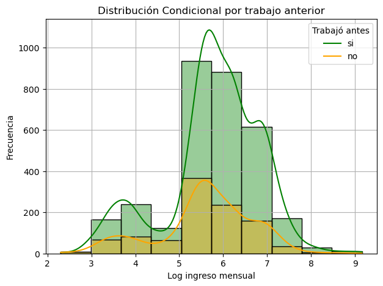

```python
plt.figure(figsize=(7, 5))
sns.histplot(filtraditos, x='log_ingreso_mensual', hue='trabajo_venezuela', kde=True, bins=10,
             palette={'si': "green", 'no': "orange"}, alpha=0.4)

# Ajustes del gráfico
plt.title("Distribución Condicional por trabajo anterior")
plt.xlabel("Log ingreso mensual")
plt.ylabel("Frecuencia")
plt.legend(labels=["si", "no"], title="Trabajó antes")
plt.grid(True)
plt.show()
```

```python
est_ingre_trabaj = filtraditos.groupby('trabajo_venezuela')['log_ingreso_mensual'].agg(
    Media='mean',
    Mediana='median',
    Desv_Est='std',
    Varianza='var',
    Mínimo='min',
    Máximo='max',
    Moda=lambda x: x.mode()[0] if not x.mode().empty else None
).reset_index()

est_ingre_trabaj = est_ingre_trabaj.round(2)
print(tabulate(est_ingre_trabaj, headers='keys', tablefmt='grid'))
```

```
+----+---------------------+---------+-----------+------------+------------+----------+----------+--------+
|    | trabajo_venezuela   |   Media |   Mediana |   Desv_Est |   Varianza |   Mínimo |   Máximo |   Moda |
+====+=====================+=========+===========+============+============+==========+==========+========+
|  0 | no                  |    5.6  |      5.7  |       1.09 |       1.18 |      2.3 |     8.85 |    5.7 |
+----+---------------------+---------+-----------+------------+------------+----------+----------+--------+
|  1 | si                  |    5.79 |      5.86 |       1.08 |       1.16 |      2.3 |     9.16 |    5.7 |
+----+---------------------+---------+-----------+------------+------------+----------+----------+--------+
```

### 3.2. En relación al número de horas de trabajo por semana

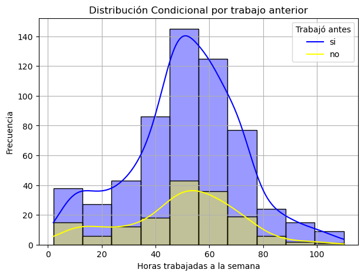

```python
plt.figure(figsize=(7, 5))
sns.histplot(filtraditos, x='horas_trabaja_sem', hue='trabajo_venezuela', kde=True, bins=10,
             palette={'si': "blue", 'no': "yellow"}, alpha=0.4)

# Ajustes del gráfico
plt.title("Distribución Condicional por trabajo anterior")
plt.xlabel("Horas trabajadas a la semana")
plt.ylabel("Frecuencia")
plt.legend(labels=["si", "no"], title="Trabajó antes")
plt.grid(True)
plt.show()
```

```python
est_hora_trabajo = filtraditos.groupby('trabajo_venezuela')['horas_trabaja_sem'].agg(
    Media='mean',
    Mediana='median',
    Desv_Est='std',
    Varianza='var',
    Mínimo='min',
    Máximo='max',
    Moda=lambda x: x.mode()[0] if not x.mode().empty else None
).reset_index()

est_hora_trabajo = est_hora_trabajo.round(2)
print(tabulate(est_hora_trabajo, headers='keys', tablefmt='grid'))
```

```
+----+---------------------+---------+-----------+------------+------------+----------+----------+--------+
|    | trabajo_venezuela   |   Media |   Mediana |   Desv_Est |   Varianza |   Mínimo |   Máximo |   Moda |
+====+=====================+=========+===========+============+============+==========+==========+========+
|  0 | no                  |   49.15 |        50 |      20.61 |     424.82 |        4 |      100 |     60 |
+----+---------------------+---------+-----------+------------+------------+----------+----------+--------+
|  1 | si                  |   51.23 |        51 |      20.55 |     422.19 |        2 |      110 |     60 |
+----+---------------------+---------+-----------+------------+------------+----------+----------+--------+
```

## 4 Trabajo Formal

### 4.1. En relación a ingreso mensual

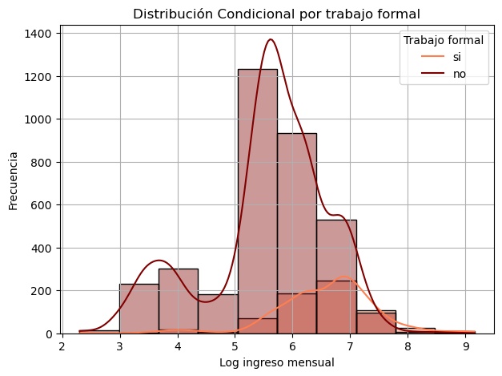

```python
plt.figure(figsize=(7, 5))
sns.histplot(filtraditos, x='log_ingreso_mensual', hue='firma_contrato', kde=True, bins=10,
             palette={'si': "coral", 'no': "maroon"}, alpha=0.4)

# Ajustes del gráfico
plt.title("Distribución Condicional por trabajo formal")
plt.xlabel("Log ingreso mensual")
plt.ylabel("Frecuencia")
plt.legend(labels=["si", "no"], title="Trabajo formal")
plt.grid(True)
plt.show()
```

```python
est_ingreso_formal = filtraditos.groupby('firma_contrato')['log_ingreso_mensual'].agg(
    Media='mean',
    Mediana='median',
    Desv_Est='std',
    Varianza='var',
    Mínimo='min',
    Máximo='max',
    Moda=lambda x: x.mode()[0] if not x.mode().empty else None
).reset_index()

est_ingreso_formal = est_ingreso_formal.round(2)
print(tabulate(est_ingreso_formal, headers='keys', tablefmt='grid'))
```

```
+----+------------------+---------+-----------+------------+------------+----------+----------+--------+
|    | firma_contrato   |   Media |   Mediana |   Desv_Est |   Varianza |   Mínimo |   Máximo |   Moda |
+====+==================+=========+===========+============+============+==========+==========+========+
|  0 | no               |    5.58 |      5.7  |       1.05 |       1.1  |      2.3 |     8.99 |   5.7  |
+----+------------------+---------+-----------+------------+------------+----------+----------+--------+
|  1 | si               |    6.6  |      6.75 |       0.84 |       0.71 |      3.4 |     9.16 |   6.84 |
+----+------------------+---------+-----------+------------+------------+----------+----------+--------+
```

- Quienes tienen trabajo formal tiene valores más altos en el Log de ingreso mensual. Esto se refuerza con la diferencia en las medianas.
- Hay más variabilidad entre los que no tienen un trabajo formal. Esto puede explicarse porque, en el mercado informal, no se respeta el mínimo vital y la remuneración varía entre la naturaleza del trabajo por realizar.

### 4.2. En relación a horas trabajadas por semana

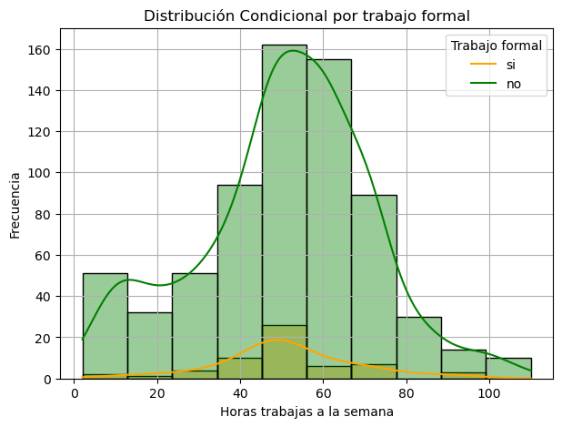

```python
plt.figure(figsize=(7, 5))
sns.histplot(filtraditos, x='horas_trabaja_sem', hue='firma_contrato', kde=True, bins=10,
             palette={'si': "orange", 'no': "green"}, alpha=0.4)

# Ajustes del gráfico
plt.title("Distribución Condicional por trabajo formal")
plt.xlabel("Horas trabajas a la semana")
plt.ylabel("Frecuencia")
plt.legend(labels=["si", "no"], title="Trabajo formal")
plt.grid(True)
plt.show()
```

```python
est_trabajo_formal = filtraditos.groupby('firma_contrato')['horas_trabaja_sem'].agg(
    Media='mean',
    Mediana='median',
    Desv_Est='std',
    Varianza='var',
    Mínimo='min',
    Máximo='max',
    Moda=lambda x: x.mode()[0] if not x.mode().empty else None
).reset_index()

est_trabajo_formal = est_trabajo_formal.round(2)
print(tabulate(est_trabajo_formal, headers='keys', tablefmt='grid'))
```

```
+----+------------------+---------+-----------+------------+------------+----------+----------+--------+
|    | firma_contrato   |   Media |   Mediana |   Desv_Est |   Varianza |   Mínimo |   Máximo |   Moda |
+====+==================+=========+===========+============+============+==========+==========+========+
|  0 | no               |   50.75 |        52 |      20.88 |     435.78 |        2 |      110 |     60 |
+----+------------------+---------+-----------+------------+------------+----------+----------+--------+
|  1 | si               |   51.25 |        50 |      16.66 |     277.43 |       10 |       91 |     48 |
+----+------------------+---------+-----------+------------+------------+----------+----------+--------+
```

- Las media y la mediana son cercanas en los casos en los que tienen trabajo formal y los que no.
- Quienes no tienen trabajo formal muestran una mayor variabilidad en las horas, lo que podría explicarse por la demanda heterogénea que tienen los trabajos informales entre si.

## 5. Reto

Primero procedemos a comprobar la normalidad de distribución

```python
from scipy.stats import shapiro

stat, p = shapiro(filtraditos['log_ingreso_mensual'])
if p > 0.05:
    print("Distribución normal")
else:
    print("Distribución no normal")
```

```
Distribución no normal
```

Como no cumple con la normalidad, utilizamos una prueba no paramétrica como es el caso de Mann- Whitney U test

### 5.1. Variable: Sexo

- H0: No hay diferencia en el ingreso promedio mensual entre hombres y mujeres.
- H1: Hay una diferencia en el ingreso promedio mensual entre hombres y mujeres.

```python
from scipy.stats import ttest_ind, mannwhitneyu

hombres = filtraditos[filtraditos['sexo'] == 'hombre']['log_ingreso_mensual']
mujeres = filtraditos[filtraditos['sexo'] == 'mujer']['log_ingreso_mensual']
```

```python
print(hombres.isnull().sum(), mujeres.isnull().sum())
hombres = hombres.dropna()
mujeres = mujeres.dropna()
```

```
3334 4086
```

```python
# Prueba no paramétrica
stat, p = mannwhitneyu(hombres, mujeres)
print('Mann-Whitney U:', stat, p)
```

```
Mann-Whitney U: 2411303.0 3.0031852587768035e-10
```

Como el p-valor es menor que 0.05, rechazas la hipótesis nula (H0). Esto significa que existe una diferencia significativa en los ingresos mensuales (transformados como logaritmo) entre hombres y mujeres.

### 5.2. Variable: Trabajo previo

- H0: La distribución del ingreso es igual para ambos grupos
- H1: La distribución del ingreso es diferente entre los dos grupos

```python
previo_si = filtraditos[filtraditos['trabajo_venezuela'] == 'si']['log_ingreso_mensual']
previo_no = filtraditos[filtraditos['trabajo_venezuela'] == 'no']['log_ingreso_mensual']
```

```python
print(previo_si.isnull().sum(), previo_no.isnull().sum())
previo_si = previo_si.dropna()
previo_no = previo_no.dropna()
```

```
2675 4745
```

```python
# Prueba no paramétrica
stat, p = mannwhitneyu(previo_si, previo_no)
print('Mann-Whitney U:', stat, p)
```

```
Mann-Whitney U: 1830113.5 1.0534549645899207e-09
```

Dado que el p-valor es menor que 0.05, rechazamos la hipótesis nula, lo que nos indica que existen diferencias significativas en el ingreso mensual (transformado a logaritmo) entre aquellas personas que trabajaron previamente en Venezuela y quienes no lo hicieron.

### 5.3. Variable: Trabajo formal

- H0: No hay diferencia en el ingreso promedio mensual entre quienes tienen trabajo formal y quienes no.
- H1: Hay una diferencia en el ingreso promedio mensual entre estos grupos.

```python
formal = filtraditos[filtraditos['firma_contrato'] == 'si']['log_ingreso_mensual']
informal = filtraditos[filtraditos['firma_contrato'] == 'no']['log_ingreso_mensual']
```

```python
print(formal.isnull().sum(), informal.isnull().sum())
formal = formal.dropna()
informal = informal.dropna()
```

```
1 7419
```

```python
# Prueba no paramétrica
stat, p = mannwhitneyu(formal, informal)
print('Mann-Whitney U:', stat, p)
```

```
Mann-Whitney U: 1871229.0 3.0323228000837256e-127
```

Dado que el p-valor es menor que 0.05, rechazamos la hipótesis nula (H0). Esto significa que hay una diferencia estadísticamente significativa en el ingreso mensual (o su transformación logarítmica) entre quienes tienen trabajo formal e informal.